# Practical Machine Learning Project

Alex McBride

Sunday, April 19, 2015

## Synopsis

Using devices such as Jawbone Up, Nike FuelBand, and Fitbit it is now possible to collect a large amount of data about personal activity relatively inexpensively. These type of devices are part of the quantified self movement – a group of enthusiasts who take measurements about themselves regularly to improve their health, to find patterns in their behavior, or because they are tech geeks. One thing that people regularly do is quantify how much of a particular activity they do, but they rarely quantify how well they do it. In this project, the goal will be to use data from accelerometers on the belt, forearm, arm, and dumbell of 6 participants. They were asked to perform barbell lifts correctly and incorrectly in 5 different ways. More information is available from the website here: http://groupware.les.inf.puc-rio.br/har (see the section on the Weight Lifting Exercise Dataset).

The data for this project come from this source: http://groupware.les.inf.puc-rio.br/har. If you use this document for any other purpose please cite them as they have been very generous in allowing their data to be used for this kind of assignment.

### Load the Library’s

```r
library(caret)
library(randomForest)
```

```r
library(rpart)
library(rpart.plot)
```

### Download the data

```r
trainUrl <-"https://d396qusza40orc.cloudfront.net/predmachlearn/pml-training.csv"
testUrl <- "https://d396qusza40orc.cloudfront.net/predmachlearn/pml-testing.csv"
trainFile <- "./pml-training.csv"
testFile  <- "./pml-testing.csv"

if (!file.exists(trainFile)) {
  download.file(trainUrl, destfile=trainFile, method="curl")
}
if (!file.exists(testFile)) {
  download.file(testUrl, destfile=testFile, method="curl")
}
```

### Read, Explore and Clean the Data

```r
trainingRaw <- read.csv(file="pml-training.csv", header=TRUE, as.is = TRUE,
                        stringsAsFactors = FALSE, sep=',', na.strings=c('NA','','#DIV/0!'))
testingRaw <- read.csv(file="pml-testing.csv", header=TRUE, as.is = TRUE,
                       stringsAsFactors = FALSE, sep=',', na.strings=c('NA','','#DIV/0!'))

dim(trainingRaw)
```

```
## [1] 19622   160
```

```r
dim(testingRaw)
```

```
## [1]  20 160
```

There are variables in the dataset that have NAs, we will remove them and be left with belt, arm, dumbbell, and forearm variables that do not have any missing values in the test dataset. They will be the predictor candidates. We will factorise the `classe` variable in the training set and include it, as this is the outcome we are training our model to. In the test set there will be a column `problem_id`, this will be the result indicator column.

```r
trainingRaw$classe <- as.factor(trainingRaw$classe)
trainClean <- trainingRaw[, colSums(is.na(trainingRaw)) == 0]
testClean <- testingRaw[, colSums(is.na(testingRaw)) == 0]
classe <- trainClean$classe
trainRemove <- grepl("^X|timestamp|window", names(trainClean))
trainClean <- trainClean[, !trainRemove]
trainClean <- trainClean[, sapply(trainClean, is.numeric)]
trainClean$classe <- classe
testRemove <- grepl("^X|timestamp|window", names(testClean))
testClean <- testClean[, !testRemove]
testClean <- testClean[, sapply(testClean, is.numeric)]
```

### Split the training data

```r
set.seed(5872) # For reproducibility
inTrain <- createDataPartition(trainClean$classe, p=0.70, list=F)
trainData <- trainClean[inTrain, ]
crossValidateData <- trainClean[-inTrain, ]
```

### Data Modeling - Random Forest

We fit a predictive model for activity recognition using the Random Forest algorithm because it automatically selects important variables and is robust to correlated covariates & outliers in general. We will use 5-fold cross validation when applying the algorithm.

```r
modFit <- train(classe~.,data = trainData, method="rf",
                        trControl = trainControl(method ="cv", 5),
                        ntree=250, do.trace=50)
```

```r
modFit
```

```
## Random Forest
##
## 13737 samples
##    52 predictor
##     5 classes: 'A', 'B', 'C', 'D', 'E'
##
## No pre-processing
## Resampling: Cross-Validated (5 fold)
##
## Summary of sample sizes: 10989, 10990, 10989, 10989, 10991
##
## Resampling results across tuning parameters:
##
##   mtry  Accuracy   Kappa      Accuracy SD  Kappa SD
##    2    0.9895176  0.9867386  0.002418410  0.003061394
##   27    0.9902455  0.9876602  0.001634285  0.002068931
##   52    0.9843494  0.9802005  0.004900938  0.006201991
##
## Accuracy was used to select the optimal model using  the largest value.
## The final value used for the model was mtry = 27.
```

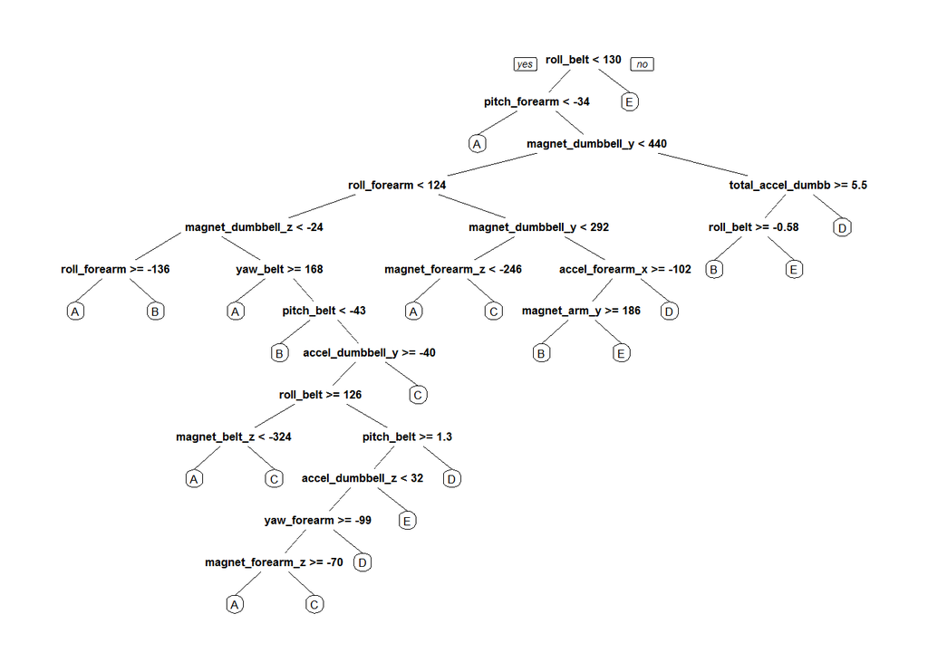

```r
treeModel <- rpart(classe ~ ., data=trainData, method="class")
prp(treeModel)
```

This tree plot shows an approximation of the Random Forest model and how it comes to its prediction answers

### Test the Predictions

```r
trainPred <- predict(modFit, trainData)
confusionMatrix(trainPred, trainData$classe)
```

```
## Confusion Matrix and Statistics
##
##           Reference
## Prediction    A    B    C    D    E
##          A 3906    0    0    0    0
##          B    0 2658    0    0    0
##          C    0    0 2396    0    0
##          D    0    0    0 2252    0
##          E    0    0    0    0 2525
##
## Overall Statistics
##
##                Accuracy : 1
##                  95% CI : (0.9997, 1)
##     No Information Rate : 0.2843
##     P-Value [Acc > NIR] : < 2.2e-16
##
##                   Kappa : 1
##  Mcnemar's Test P-Value : NA
##
## Statistics by Class:
##
##                      Class: A Class: B Class: C Class: D Class: E
## Sensitivity            1.0000   1.0000   1.0000   1.0000   1.0000
## Specificity            1.0000   1.0000   1.0000   1.0000   1.0000
## Pos Pred Value         1.0000   1.0000   1.0000   1.0000   1.0000
## Neg Pred Value         1.0000   1.0000   1.0000   1.0000   1.0000
## Prevalence             0.2843   0.1935   0.1744   0.1639   0.1838
## Detection Rate         0.2843   0.1935   0.1744   0.1639   0.1838
## Detection Prevalence   0.2843   0.1935   0.1744   0.1639   0.1838
## Balanced Accuracy      1.0000   1.0000   1.0000   1.0000   1.0000
```

```r
cvPred <- predict(modFit, crossValidateData)
confusionMatrix(cvPred, crossValidateData$classe)
```

```
## Confusion Matrix and Statistics
##
##           Reference
## Prediction    A    B    C    D    E
##          A 1673   10    0    0    0
##          B    1 1123    5    0    1
##          C    0    6 1016   15    6
##          D    0    0    5  949    5
##          E    0    0    0    0 1070
##
## Overall Statistics
##
##                Accuracy : 0.9908
##                  95% CI : (0.988, 0.9931)
##     No Information Rate : 0.2845
##     P-Value [Acc > NIR] : < 2.2e-16
##
##                   Kappa : 0.9884
##  Mcnemar's Test P-Value : NA
##
## Statistics by Class:
##
##                      Class: A Class: B Class: C Class: D Class: E
## Sensitivity            0.9994   0.9860   0.9903   0.9844   0.9889
## Specificity            0.9976   0.9985   0.9944   0.9980   1.0000
## Pos Pred Value         0.9941   0.9938   0.9741   0.9896   1.0000
## Neg Pred Value         0.9998   0.9966   0.9979   0.9970   0.9975
## Prevalence             0.2845   0.1935   0.1743   0.1638   0.1839
## Detection Rate         0.2843   0.1908   0.1726   0.1613   0.1818
## Detection Prevalence   0.2860   0.1920   0.1772   0.1630   0.1818
## Balanced Accuracy      0.9985   0.9922   0.9923   0.9912   0.9945
```

We will check this test for accuracy and the out-of-sample error

```r
accuracy <- postResample(cvPred, crossValidateData$classe)
oose <- 1 - as.numeric(confusionMatrix(crossValidateData$classe,
                                                cvPred)$overall[1])
```

From our tests on the cross validation dataset the estimated accuracy of our model is 99.1% and the out-of-sample error is 0.92%.

### Run the final test

```r
result <- predict(modFit, testClean[, -length(names(testClean))]) # -length removes problem_id
result
```

```
##  [1] B A B A A E D B A A B C B A E E A B B B
## Levels: A B C D E
```

#### Produce the answers

As a final part to the project, we will create a function to write the `results` to individual .txt files to submit for marking.

```r
pml_write_files <- function(x){
  n <- length(x)
  for(i in 1:n){
    filename = paste0("problem_id_",i,".txt")
    write.table(x[i],file=filename,quote=FALSE,row.names=FALSE,col.names=FALSE)
  }
}
pml_write_files(result)
```